# SELECT package demonstration Twin haul

## Summary

**This case study demonstrates:**

- Estimating logistic and Richards selection curves from twin-haul data.
- Fitting to catch-share curves.
- Using combined individual-haul data to estimate over-dispersion (due to causes such as sub-sampling, between-haul variability and non-independent behaviour of fish).
- Using over-dispersion adjustments.

### Data source

The data are for Eastern king prawn selectivity in a 20 mm square-mesh penaeid trawl (Broadhurst et al., 2004. Selectivity of conventional diamond- and novel square-mesh codends in an Australian estuarine penaeid-trawl fishery. Fisheries Research, 67: 183-194).

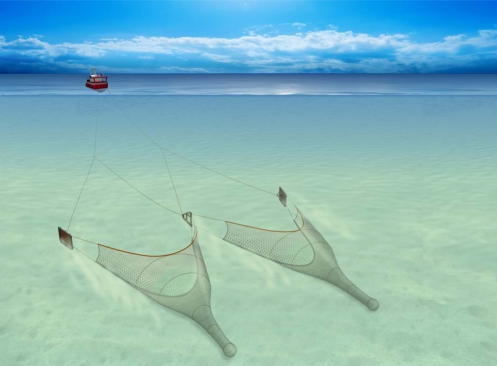

```r
require(SELECT)
require(dplyr)
```

### Input the data

```r
#Read in data and remove zero catch lengths
sqKP.df=read.csv("../Data/SqNorKP.csv",header=T) #500 by 4
sqKP.df=subset(sqKP.df,control+codend>0) #192 by 4
#Quick peek at data
head(sqKP.df)
```

|  | lgth | codend | control | PairID |
| --- | --- | --- | --- | --- |
| 10 | 10 | 0 | 6 | 1 |
| 11 | 11 | 5 | 6 | 1 |
| 12 | 12 | 11 | 11 | 1 |
| 13 | 13 | 22 | 6 | 1 |
| 14 | 14 | 13 | 14 | 1 |
| 15 | 15 | 13 | 6 | 1 |

### Define variable names

```r
v.names=c("lgth","control","codend")
```

### Produce plot of catch-share proportions

```r
Tots=Raw2Tots(sqKP.df,v.names)
Tots=transform(Tots,n=codend+control,y=codend/(codend+control))
Tots
```

| lgth | control | codend | n | y |
| --- | --- | --- | --- | --- |
| 6 | 1 | 0 | 1 | 0.0000000 |
| 7 | 4 | 1 | 5 | 0.2000000 |
| 8 | 24 | 1 | 25 | 0.0400000 |
| 9 | 33 | 6 | 39 | 0.1538462 |
| 10 | 66 | 23 | 89 | 0.2584270 |
| 11 | 104 | 55 | 159 | 0.3459119 |
| 12 | 111 | 100 | 211 | 0.4739336 |
| 13 | 116 | 105 | 221 | 0.4751131 |
| 14 | 89 | 96 | 185 | 0.5189189 |
| 15 | 73 | 76 | 149 | 0.5100671 |

[output cut: 7 more lines]

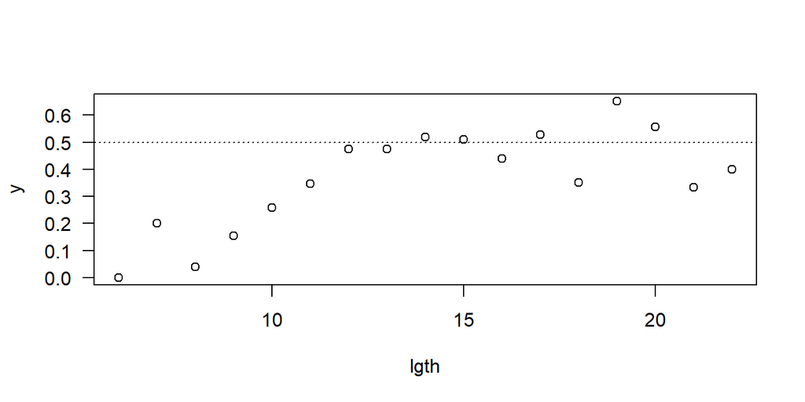

```r
plot(y~lgth,data=Tots,las=1)
abline(h=0.5,lty=3)
```

### Fit logistic selection curve

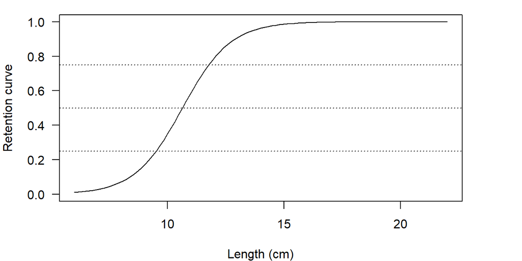

```r
par(mar=c(4,4,1,4),las=1)
Logist.fit=SELECT(Tots,var.names=v.names,dtype="ec")
plot(Logist.fit)
```

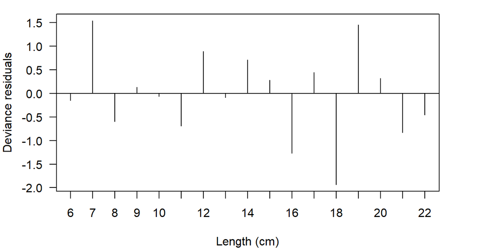

```
## Model fit:
##    null.l   model.l    full.l      npar       AIC       BIC
## -69.63410 -38.95222 -32.29383   3.00000  83.90443  86.40407
## GOF:
##      Deviance Pearson.chisq           dof   Deviance.CF    Pearson.CF
##    13.3167657    16.2189932    14.0000000     0.9511976     1.1584995
```

```r
ModelCheck(Logist.fit)
```

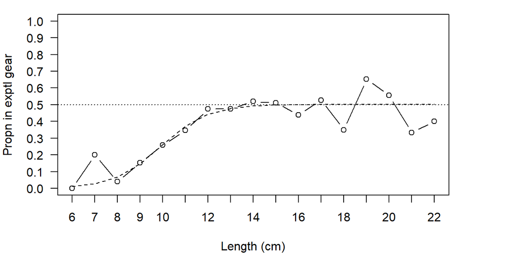

```r
abline(h=0.5,lty=3)
```

```r
Estimates(Logist.fit)
```

```
##            par  raw s.e.
## L50 10.6340407 0.3181545
## SR   2.2629652 0.4569826
## p    0.5020243 0.0200655
```

The logistic fit looks good.

### Fit Richards curve

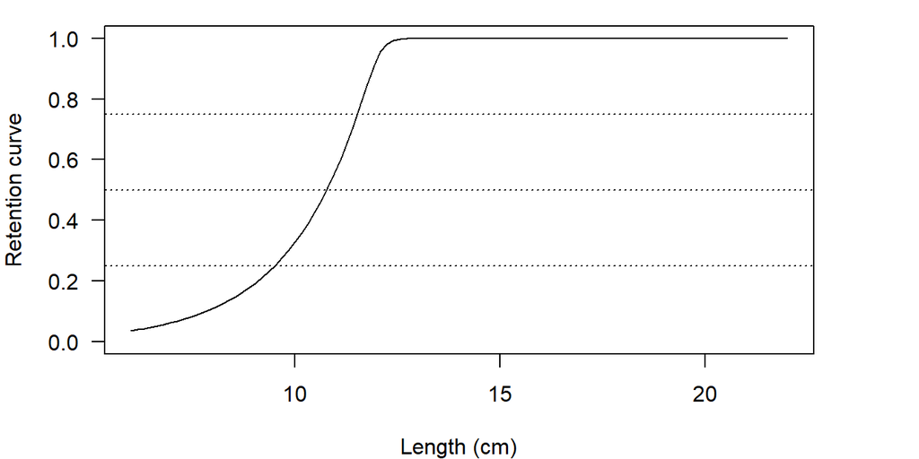

```r
Rich.fit=SELECT(Tots,var.names=v.names,dtype="ec",stype="richards")
plot(Rich.fit)
```

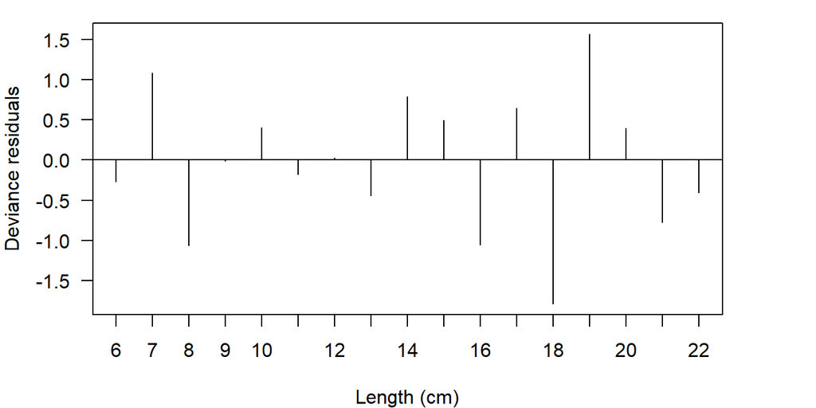

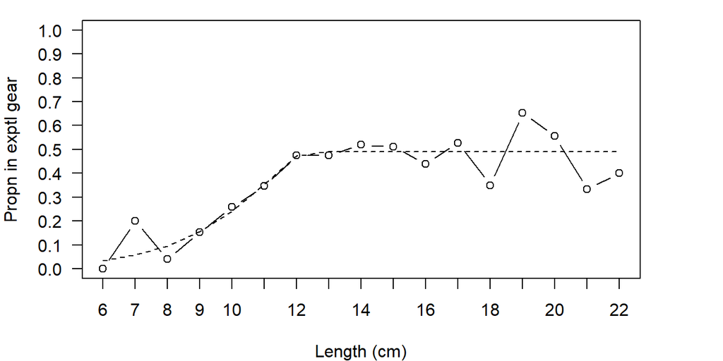

```
## Model fit:
##    null.l   model.l    full.l      npar       AIC       BIC
## -69.63410 -38.14618 -32.29383   4.00000  84.29237  87.62522
## GOF:
##      Deviance Pearson.chisq           dof   Deviance.CF    Pearson.CF
##    11.7046981    12.0196464    13.0000000     0.9003614     0.9245882
```

```r
ModelCheck(Rich.fit)
```

```r
Estimates(Rich.fit)
```

```
##              par    raw s.e.
## L50   10.7689854  0.26819278
## SR     2.0174087  0.48179535
## delta 12.4539883 36.91844960
## p      0.4899005  0.01749559
```

Even without correcting for possible over-dispersion it is clear that the extra complexity of the Richard curve is not needed. The logistic is good enough.

## Correcting for over-dispersion

### Produce a lattic plot of catch-share proportions by haul

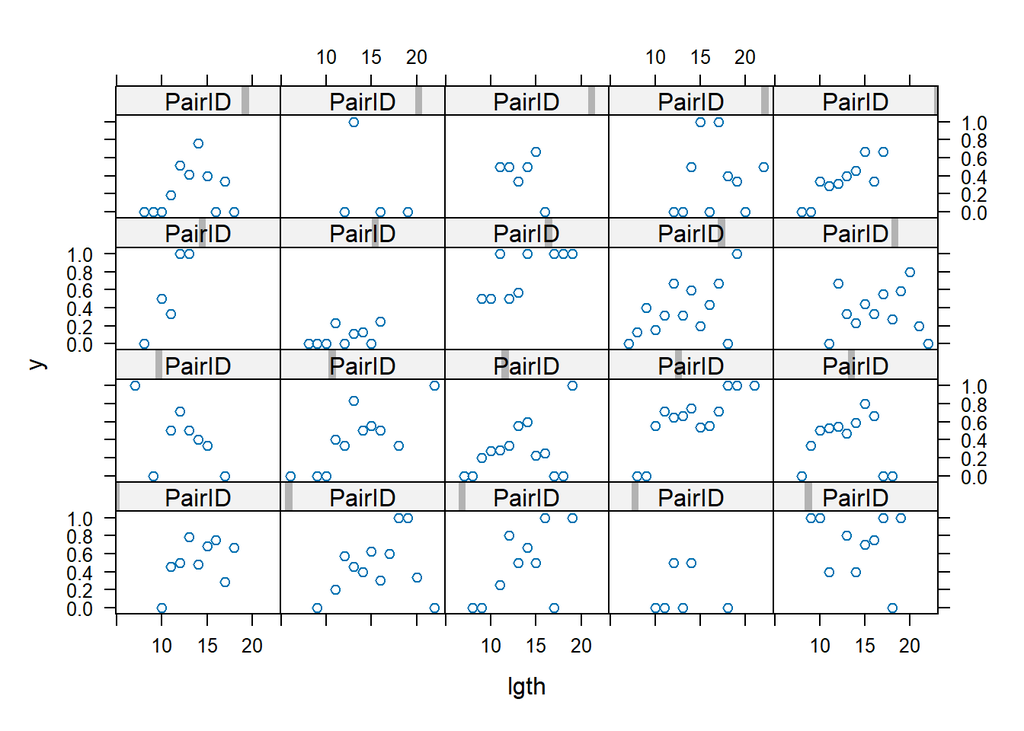

```r
HaulCatch=Raw2Tots(sqKP.df,v.names,sumHauls=F)
HaulCatch=transform(HaulCatch,n=codend+control,y=codend/(codend+control))
require(lattice) #For xyplot
xyplot(y~lgth | PairID,data=HaulCatch)
```

The retention proportions are certainly highly variable, but it is hard to distinguish BHV from within-haul variability.

### Fit a logistic selection curve to the combined individual pair data

```r
Logist.fit2=SELECT(sqKP.df,var.names=v.names,dtype="ec",sumHauls=F)
ModelCheck(Logist.fit2, minE=5, plots=F)
```

```
## Model fit:
##    null.l   model.l    full.l      npar       AIC       BIC
## -323.3478 -292.6659 -142.0254    3.0000  591.3318  601.1043
## GOF:
##      Deviance Pearson.chisq           dof   Deviance.CF    Pearson.CF
##    301.280993    282.166530    189.000000      1.594079      1.492945
##
## Correction factors from cells with expected count > 5 :
##      Deviance Pearson.chisq           dof   Deviance.CF    Pearson.CF
##     82.540482     74.852420     36.000000      2.292791      2.079234
```

The variance correction factor `Pearson.CF` shows that the actual variabilty is about twice that assumed under the binomial model. This is relatively low, and a bootstrap would probably over-estimate the standard errors.

In this case it is preferable to do a simple over-dispersion adjustment to the raw standard errors.

```r
Estimates(Logist.fit,OD=2.08)
```

```
##            par  raw s.e.   adj s.e.
## L50 10.6340407 0.3181545 0.45884892
## SR   2.2629652 0.4569826 0.65906975
## p    0.5020243 0.0200655 0.02893888
```